# E-Commerce Customer Intelligence Report

## Project Description

### The Business Problem

A UK-based online gift store has 13 months of raw transaction data sitting in a spreadsheet. Management knows their total revenue but has no visibility into **who their best customers are, why customers are not coming back, or where revenue is silently leaking out.** Without this information, every marketing and retention decision is a guess.

### What This Analysis Does

This report applies a full four-layer analytical framework to 541,909 real transactions — moving from surface-level observations to root cause diagnosis to mathematical revenue projections:

| Phase | Question Answered |
| --- | --- |
| **Descriptive** | What is actually happening in this business? |
| **Diagnostic** | Why is it happening? |
| **Prescriptive** | What should the business do about it? |
| **Predictive (CLV Model)** | What is each customer worth going forward? |

### Dataset

- **Source:** UCI Machine Learning Repository — Online Retail Dataset
- **Period:** December 2010 — December 2011
- **Size:** 541,909 raw transactions lines· 4,335 unique customers · 38 countries
- **Revenue:** £10,642,110 total across 13 months

### Tools Used

Python · Pandas · NumPy · Matplotlib · Seaborn · Jupyter Notebook

### Analyst

**CJ John Paulin** — Freelance Data Analyst  
linkedin.com/in/cjjohnpaulin · github.com/cjjohnpaulin

# Executive Summary

**Analyst:** CJ John Paulin | **Date:** 2026 | **Dataset:** UCI Online Retail — 541,909 real transactions · Dec 2010 – Dec 2011

### What This Report Covers

This report analyzes 13 months of real transaction data from a UK-based online gift store — covering **4,335 customers, 524,878 transactions after removing cancellations/returns for revenue calculations, and £10,642,110 in total revenue.** It identifies three urgent business problems the store's standard reports are not showing, and provides specific actions with projected financial impact.

### ⚠ Problem 1 — £893,980 Is Silently Leaking Out Every Year

The store lost **£893,980 to cancellations** — **7.7% of gross revenue** — across 3,836 cancellation invoices. This number does not appear in standard sales dashboards. The store's top quantity product, **PAPER CRAFT, LITTLE BIRDIE**, is simultaneously its most cancelled product at **£168,470 in lost revenue** — suggesting a fulfillment or quality issue that is costing the business on both ends.

Additionally, **34.4% of customers bought only once and never returned.** Every marketing pound spent acquiring these customers generated zero repeat value.

**Fix:** Investigate the top cancelled product immediately. Set up a post-purchase email within 7 days of first purchase to convert one-time buyers into repeat customers.

### ⚠ Problem 2 — The Entire Business Depends on 434 People

RFM analysis reveals that **1,315 Champion customers generate 72.97% of all revenue** — and the top 10% of customers (just 434 people) account for **61.4% of annual revenue (£5,367,688).** The business does not know who these people are or have any formal system to keep them.

Meanwhile, **765 At Risk customers representing £929,327 in revenue are quietly drifting away** — still reachable but going silent.

**Fix:** Identify Champions by name using the RFM list in this report. Launch a VIP loyalty program this month. Send a win-back campaign to At Risk customers within 30 days before they become Lost.

### ✅ Opportunity — £2,107,329 in Recoverable Revenue

Acting on the recommendations in this report — three targeted email campaigns over 90 days — is projected to recover **£2,107,329 in additional annual revenue** under the Realistic scenario:

| Action | What Changes | Revenue Recovered |
| --- | --- | --- |
| Post-purchase email sequence | Retention 21.8% → 30% | £1,518,196 |
| At Risk win-back campaign | 20% of 765 customers return | £185,866 |
| Loyal upsell bundles | 100 customers move to Champion spend | £403,267 |
| **Total** |  | **£2,107,329** |

The Customer Lifetime Value model confirms a **Champion is worth £4,367 per year** — making a £50 VIP reward a **8,634% return on investment.**

**1.** Export the Champion customer list from the RFM analysis and send a personal thank-you email this week. These 1,315 customers generate £6,380,162 annually — they deserve to know they are valued.

**2.** Set up one automated email triggered 7 days after a customer's first purchase. Even moving Month 1 retention from 21.8% to 30% recovers **£1,518,196 per year** — automatically, every month, with no ongoing effort.

### Bottom Line

*Full methodology, data cleaning audit, and supporting analysis available in sections D1–P3 of this report.*

# Phase 1 — Descriptive Analysis — What happened?

# D1 - Revenue Overview

**Objective:** Understand how total revenue changed across 12 months and identify seasonal patterns in the business.

**Key metric:** Monthly revenue = sum of (Quantity × UnitPrice)

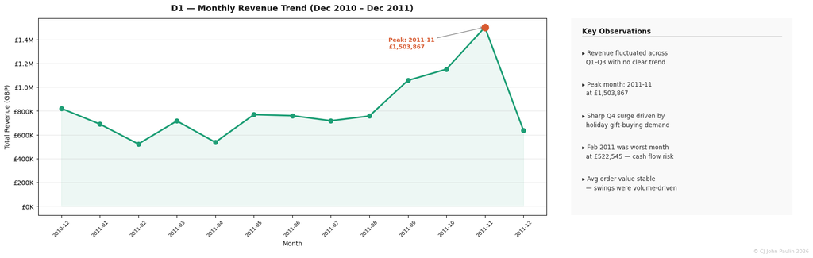

D1 — Monthly Revenue Summary

|  | Month | Total Revenue (£) | Total Orders | Avg Order Value (£) |
| --- | --- | --- | --- | --- |
| 0 | 2010-12 | £821,452.73 | 1,559 | £20.04 |
| 1 | 2011-01 | £689,811.61 | 1,086 | £20.25 |
| 2 | 2011-02 | £522,545.56 | 1,100 | £19.44 |
| 3 | 2011-03 | £716,215.26 | 1,454 | £20.18 |
| 4 | 2011-04 | £536,968.49 | 1,246 | £18.59 |
| 5 | 2011-05 | £769,296.61 | 1,681 | £21.42 |
| 6 | 2011-06 | £760,547.01 | 1,533 | £21.29 |
| 7 | 2011-07 | £718,076.12 | 1,475 | £18.70 |
| 8 | 2011-08 | £757,841.38 | 1,361 | £22.12 |
| 9 | 2011-09 | £1,056,435.19 | 1,837 | £21.60 |
| 10 | 2011-10 | £1,151,263.73 | 2,040 | £19.67 |
| 11 | 2011-11 | £1,503,866.78 | 2,769 | £18.34 |
| 12 | 2011-12 | £637,790.33 | 819 | £25.68 |

D1 — Key Metrics

|  | Metric | Value |
| --- | --- | --- |
| 0 | Total Annual Revenue | £10,642,110.80 |
| 1 | Best Month | 2011-11 — £1,503,866.78 |
| 2 | Worst Month | 2011-02 — £522,545.56 |
| 3 | Total Orders | 19,960 |

## D1 Insights — Monthly Revenue Trend

### What the data shows

Revenue fluctuated across the first three quarters of 2011 with no consistent upward trend, before surging sharply in **Q4 (Sep–Nov 2011)**. The business shows a clear **seasonal concentration pattern** rather than steady growth.

### Key Findings

- **Peak month: November 2011** at **£1,503,866** — nearly 3x the worst performing month
- **Worst month: February 2011** at **£522,545** — the deepest revenue trough in the dataset
- **Q4 surge (Sep–Nov)** drove disproportionate annual revenue, consistent with holiday gift-buying behavior for a gift store
- **Total annual revenue: £10,642,110** across 13 months of trading
- **Average order value remained stable** at £18–25 throughout the year — revenue swings were driven by **order volume**, not spending per order

### This means...

The business is **heavily seasonal and volatile** — Q4 carries a disproportionate share of annual revenue while February represents a significant cash flow risk. A store this dependent on Q4 demand needs either a **mid-year promotional strategy** to smooth revenue gaps or **lean inventory planning** for slow months to protect margins.

# D2 — Product Performance

**Objective:** Identify the **top 10 products by revenue** and **top 10 by quantity sold** — and determine whether high-volume products are the same as high-revenue products.

**Key insight to watch:** A product ranking #1 in quantity may not rank #1 in revenue — that tension reveals **pricing and margin strategy.**

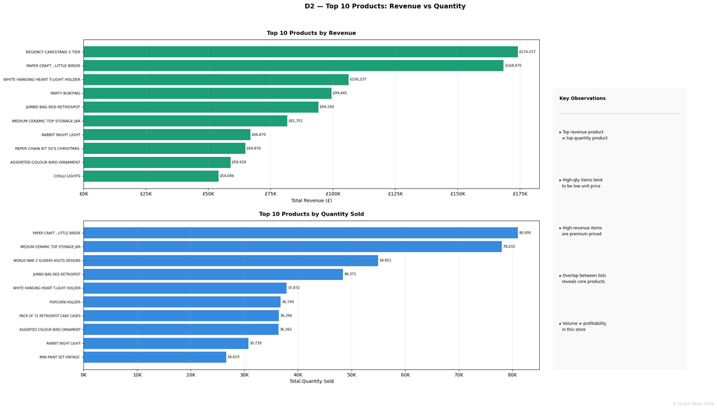

Core Products — Appear in Both Revenue and Quantity Top 10

|  | Products in BOTH Top 10 Lists |
| --- | --- |
| 0 | ASSORTED COLOUR BIRD ORNAMENT |
| 1 | JUMBO BAG RED RETROSPOT |
| 2 | MEDIUM CERAMIC TOP STORAGE JAR |
| 3 | PAPER CRAFT , LITTLE BIRDIE |
| 4 | RABBIT NIGHT LIGHT |
| 5 | WHITE HANGING HEART T-LIGHT HOLDER |

## D2 Insights — Product Performance

### Key Findings

- **Top revenue product:** "REGENCY CAKESTAND 3 TIER" generating **£174,156.54** in total sales
- **Top quantity product:** "PAPER CRAFT , LITTLE BIRDIE" with **80,995** units sold
- **6 products** appear in both top 10 lists — these are the store's **core products** driving both volume and revenue simultaneously
- Products in the revenue list but not the quantity list are **high-margin premium items** — fewer sales, higher value per sale

### This means...

The store has two distinct product tiers — **volume drivers** and **revenue drivers**. A client managing this store should protect inventory for products appearing in both lists first, since losing stock on those items simultaneously hurts both revenue and order volume.

# D3 — Geographic Analysis

**Objective:** Identify which countries generate the most revenue **outside the UK** and assess the store's international footprint.

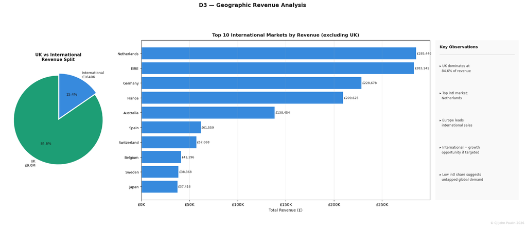

UK vs International Revenue Split

|  | Market | Total Revenue (£) | Revenue Share |
| --- | --- | --- | --- |
| 0 | United Kingdom | £9,001,744.09 | 84.6% |
| 1 | International | £1,640,366.71 | 15.4% |
| 2 | Total | £10,642,110.80 | 100.0% |

Top 10 International Markets (excluding UK)

|  | Country | Total Revenue (£) | Total Orders | Unique Customers | Rev per Customer (£) |
| --- | --- | --- | --- | --- | --- |
| 1 | Netherlands | £285,446.34 | 94 | 9 | £31,716.26 |
| 2 | EIRE | £283,140.52 | 288 | 3 | £94,380.17 |
| 3 | Germany | £228,678.40 | 457 | 94 | £2,432.75 |
| 4 | France | £209,625.37 | 392 | 87 | £2,409.49 |
| 5 | Australia | £138,453.81 | 57 | 9 | £15,383.76 |
| 6 | Spain | £61,558.56 | 90 | 30 | £2,051.95 |
| 7 | Switzerland | £57,067.60 | 54 | 21 | £2,717.50 |
| 8 | Belgium | £41,196.34 | 98 | 25 | £1,647.85 |
| 9 | Sweden | £38,367.83 | 36 | 8 | £4,795.98 |
| 10 | Japan | £37,416.37 | 19 | 8 | £4,677.05 |

## D3 Insights — Geographic Revenue Analysis

### What the data shows

The store is overwhelmingly **UK-dependent** — the United Kingdom accounts for approximately **84.6% of total revenue**. International markets collectively contribute a small but meaningful share, led by **European countries** dominating the top international markets list.

### Key Findings

- **United Kingdom:** £9,001,744.09 — **84.6%** of total revenue
- **Top international market:** Netherlands at **£285,446.34**
- **European dominance:** 8 of the top 10 international markets are European, reflecting the store's geographic proximity advantage
- **EIRE and Netherlands show wholesale buyer patterns** — EIRE generates £283,140 from only **3 customers** (£94,380 avg per customer) while Germany generates £228,678 from **94 customers** (£2,433 avg). This **39x difference** in revenue per customer suggests EIRE and Netherlands are **bulk wholesale accounts**, not retail consumers

### This means...

The store's heavy **UK concentration is both a strength and a risk** — stable domestic demand but significant vulnerability if UK consumer sentiment shifts. International expansion requires **two distinct strategies** — a **wholesale partnership approach** for markets like EIRE and Netherlands where bulk buyers already exist, and a **retail marketing approach** for Germany and France where broad consumer demand is present but underdeveloped.

# D4 — Cancellation Analysis

**Objective:** Quantify the **revenue impact of cancellations** and identify which months, countries, and products are most affected.

**Key metric:** Revenue lost = absolute value of (Quantity × UnitPrice)  
**Why this matters:** Cancellations represent **real lost revenue** that rarely appears in standard sales reports — making this one of the most actionable findings for a store owner.

[figure not shown]

## D4 Insights — Order Cancellations

### What We Found

Over the 13-month period, the business lost **£893,980** from cancelled orders.

This represents **7.7% of total revenue**, meaning that for every **£13 earned, about £1 was later lost through cancellations**.

Because cancelled orders are often hidden within sales reports, this is one of the biggest opportunities to recover lost revenue.

### Business Impact

A **7.7% cancellation rate** is a significant revenue leak.

The biggest opportunity appears to be **PAPER CRAFT, LITTLE BIRDIE**, which is both a top-selling and top-cancelled product. Investigating why customers cancel this item could help recover a substantial portion of the **£168,470 currently being lost**.

### Recommended Actions

1. Review the cancellation reasons for **PAPER CRAFT, LITTLE BIRDIE**.
2. Check for stock availability, fulfillment delays, or quality issues.
3. Analyze discount-related cancellations separately to identify avoidable reversals.
4. Monitor cancellations during peak sales periods, especially around the holiday season.
5. Set a target to reduce the cancellation rate from **7.7% to below 7%**, which could generate meaningful additional revenue.

# D5 — Customer Purchase Behavior

**Objective:** Understand how many **unique customers** the store has, how frequently they purchase, and whether a small group of **high-frequency buyers** drives a disproportionate share of orders.

**Key metric:** Purchase frequency = number of unique invoices per customer  
**Why this matters:** The distribution shape directly determines whether an **RFM segmentation strategy** is worth pursuing — if purchase behavior is uniform, segmentation adds little value. If it is heavily skewed, segmentation is essential.

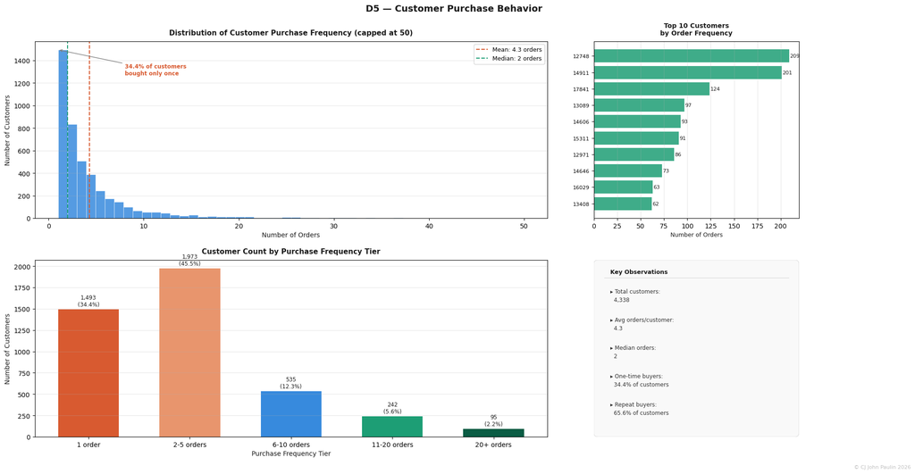

D5 — Customer Purchase Summary

|  | Metric | Value |
| --- | --- | --- |
| 0 | Total Unique Customers | 4,338 |
| 1 | Average Orders per Customer | 4.27 |
| 2 | Median Orders per Customer | 2 |
| 3 | One-time Buyers | 1,493 (34.4%) |
| 4 | Repeat Buyers | 2,845 (65.6%) |
| 5 | Highest Order Count (single customer) | 209 orders |

D5 — Customer Frequency Tier Breakdown

|  | Frequency Tier | Customer Count | Percentage |
| --- | --- | --- | --- |
| 0 | 1 order | 1493 | 34.4% |
| 1 | 2-5 orders | 1973 | 45.5% |
| 2 | 6-10 orders | 535 | 12.3% |
| 3 | 11-20 orders | 242 | 5.6% |
| 4 | 20+ orders | 95 | 2.2% |

## D5 Insights — Customer Purchase Behavior

### What the data shows

"Note: 3 CustomerIDs were later excluded from RFM/CLV analysis due to missing values, resulting in 4,335 customers in subsequent sections."

### This means...

# Phase 2 — Diagnostic Analysis —Why it Happened?

# G1 — RFM Analysis — Customer Segmentation

**Objective:** Score every customer on **Recency, Frequency, and Monetary** value to identify which customers are Champions, Loyal, At Risk, Lost, or inactive.

**Technique:** RFM Scoring — each customer receives a score of 1–4 on each dimension. Combined scores determine their segment.

| Dimension | Definition | High Score Means |
| --- | --- | --- |
| **Recency (R)** | Days since last purchase | Bought recently |
| **Frequency (F)** | Number of unique orders | Buys often |
| **Monetary (M)** | Total revenue generated | Spends more |

**Why this matters:** Without RFM, every customer looks the same. With RFM, the business knows exactly **who to retain, who to reactivate, and who to let go.**

```
 RFM Base Metrics
________________________
       CustomerID  recency  frequency   monetary
count     4335.00  4335.00    4335.00    4335.00
mean     15299.37    92.71       4.25    2017.09
std       1721.81   100.21       7.65    8919.39
min      12346.00     1.00       1.00       3.75
25%      13812.50    18.00       1.00     304.25
50%      15298.00    51.00       2.00     663.61
75%      16778.50   143.00       5.00    1631.48
max      18287.00   374.00     206.00  279138.02

 Segment Distribution
________________________
Segment
Champions           1315
At Risk              765
Loyal                608
Lost — Was Loyal     563
Lost                 516
Needs Attention      309
New Customers        259
Name: count, dtype: int64
```

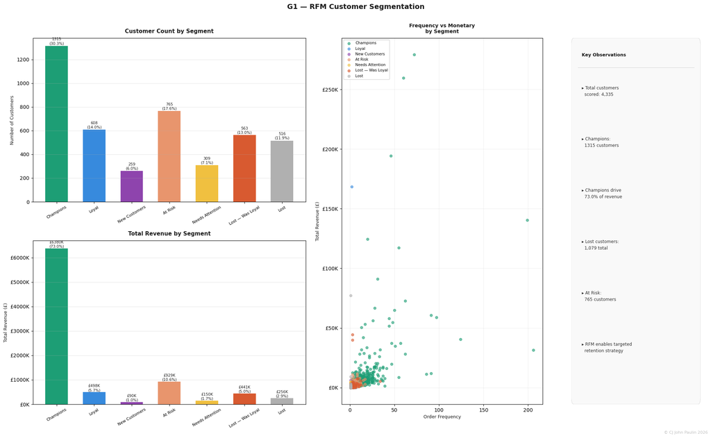

G1 — RFM Segment Summary

|  | Segment | Customers | Avg Recency (days) | Avg Frequency | Avg Monetary (£) | Revenue Share (%) |
| --- | --- | --- | --- | --- | --- | --- |
| 0 | At Risk | 765 | 84.220000 | 3.270000 | £1,214.81 | 10.63% |
| 1 | Champions | 1315 | 17.030000 | 9.340000 | £4,851.83 | 72.97% |
| 2 | Lost | 516 | 263.310000 | 1.000000 | £496.12 | 2.93% |
| 3 | Lost — Was Loyal | 563 | 233.780000 | 2.190000 | £782.48 | 5.04% |
| 4 | Loyal | 608 | 23.320000 | 2.170000 | £819.16 | 5.70% |
| 5 | Needs Attention | 309 | 85.410000 | 1.000000 | £485.94 | 1.72% |
| 6 | New Customers | 259 | 27.060000 | 1.000000 | £346.92 | 1.03% |

Top 10 Champions by Revenue

|  | Customer ID | Recency (days) | Orders | Total Revenue (£) |
| --- | --- | --- | --- | --- |
| 1 | 14646 | 2 | 72 | £279,138.02 |
| 2 | 18102 | 1 | 60 | £259,657.30 |
| 3 | 17450 | 8 | 46 | £194,390.79 |
| 4 | 14911 | 1 | 199 | £140,336.83 |
| 5 | 12415 | 24 | 20 | £124,564.53 |
| 6 | 14156 | 10 | 55 | £117,210.08 |
| 7 | 17511 | 3 | 31 | £91,062.38 |
| 8 | 16029 | 39 | 62 | £72,708.09 |
| 9 | 16684 | 4 | 28 | £66,653.56 |
| 10 | 13694 | 4 | 50 | £65,039.62 |

## G1 Insights

### What the data shows

RFM scoring reveals that the store's **4,335 customers** are not equal — they fall into distinct behavioral segments with dramatically different revenue contributions. A small group of **Champions** generates a disproportionate share of total revenue while a combined **1,079 Lost customers** represent recoverable revenue if reactivated.

### Segment Breakdown

| Segment | Customers | Avg Recency | Avg Orders | Avg Spend | Revenue Share |
| --- | --- | --- | --- | --- | --- |
| Champions | 1,315 | 17 days | 9.34 | £4,851 | 72.97% |
| At Risk | 765 | 84 days | 3.27 | £1,214 | 10.63% |
| Loyal | 608 | 23 days | 2.17 | £819 | 5.70% |
| Lost — Was Loyal | 563 | 234 days | 2.19 | £782 | 5.04% |
| Lost | 516 | 263 days | 1.00 | £496 | 2.93% |
| Needs Attention | 309 | 85 days | 1.00 | £485 | 1.72% |
| New Customers | 259 | 27 days | 1.00 | £347 | 1.03% |

- **Champions (1,315 customers)** — bought recently (avg 17 days ago), buy often (9.34 orders avg), and spend the most (£4,851 avg). They drive **72.97% of total revenue** despite representing only **30.3% of the customer base.** These are the store's most critical asset — losing even 10% of Champions would erase approximately **£638,000 in annual revenue.**
- **At Risk (765 customers)** — previously active buyers whose recency has slipped to **84 days on average.** They still have reasonable frequency (3.27 orders) and spend (£1,214 avg) but are drifting. They represent **£929,327 in revenue at risk** — the highest recoverable amount of any non-Champion segment.
- **Loyal (608 customers)** — recent buyers (23 days avg) with moderate frequency. Second most recent segment after Champions. Prime candidates for upselling — they are engaged but spending significantly less than Champions (£819 vs £4,851 avg).
- **Lost — Was Loyal (563 customers)** — formerly frequent buyers now silent for **234 days on average.** They have purchase history and brand familiarity making them more recoverable than pure Lost customers. A win-back campaign targeting this segment could recover a portion of the **£440,538** they previously spent.
- **Lost (516 customers)** — absent for **263 days** with only 1 average order. Lowest recovery probability — minimal retention investment recommended here.
- **New Customers (259 customers)** — recent first-time buyers (27 days avg) who have not yet returned. The critical window to convert them to Loyal or Champion status is **now** — engagement in the first 30 days after purchase significantly increases repeat purchase probability.

### This means...

The store has a **three-priority retention strategy** hiding in this data. First — **protect Champions** through exclusive loyalty rewards and early access programs before competitors target them. Second — **reactivate At Risk customers immediately** since their £929,327 at-risk revenue is still recoverable within a 30-day window. Third — **convert New Customers within 30 days** through targeted follow-up campaigns before the 34.4% one-time buyer pattern from D5 claims another cohort.

# G2 — Cohort Retention Analysis

**Objective:** Track how many customers who made their **first purchase in a given month** returned to buy again in subsequent months.

**Technique:** Cohort analysis — customers are grouped by their **first purchase month** and tracked month by month for retention.

**Why this matters:** Retention rate directly determines **customer lifetime value**. A store retaining 40% of customers month-over-month is fundamentally more valuable than one retaining 20% — even with identical acquisition numbers.

```
 Cohort Size by Month
_____________________
CohortMonth
2010-12    885.0
2011-01    416.0
2011-02    380.0
2011-03    452.0
2011-04    300.0
2011-05    284.0
2011-06    242.0
2011-07    187.0
2011-08    169.0
2011-09    299.0
2011-10    357.0
2011-11    323.0
2011-12     41.0
Freq: M, Name: 0, dtype: float64
```

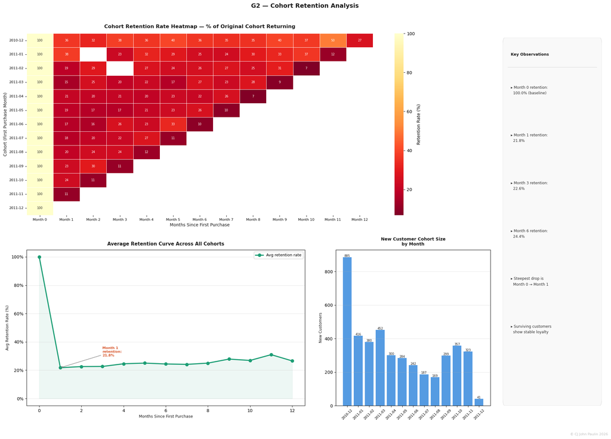

New Customer Cohort Sizes by Month

|  | Cohort Month | New Customers |
| --- | --- | --- |
| 0 | 2010-12 | 885 |
| 1 | 2011-01 | 416 |
| 2 | 2011-02 | 380 |
| 3 | 2011-03 | 452 |
| 4 | 2011-04 | 300 |
| 5 | 2011-05 | 284 |
| 6 | 2011-06 | 242 |
| 7 | 2011-07 | 187 |
| 8 | 2011-08 | 169 |
| 9 | 2011-09 | 299 |
| 10 | 2011-10 | 357 |
| 11 | 2011-11 | 323 |
| 12 | 2011-12 | 41 |

Average Retention Rate by Month Across All Cohorts

|  | Months Since First Purchase | Avg Retention Rate |
| --- | --- | --- |
| 0 | 0 | 100.0% |
| 1 | 1 | 21.8% |
| 2 | 2 | 22.6% |
| 3 | 3 | 22.6% |
| 4 | 4 | 24.5% |
| 5 | 5 | 25.0% |
| 6 | 6 | 24.4% |
| 7 | 7 | 24.1% |
| 8 | 8 | 25.0% |
| 9 | 9 | 27.8% |
| 10 | 10 | 26.9% |
| 11 | 11 | 31.0% |
| 12 | 12 | 26.6% |

Dec 2010 Cohort — Strongest Retention Detail

|  | Month Index | Retention Rate (%) |
| --- | --- | --- |
| 0 | Month 0 | 100.0% |
| 1 | Month 1 | 36.5% |
| 2 | Month 2 | 32.3% |
| 3 | Month 3 | 38.3% |
| 4 | Month 4 | 36.2% |
| 5 | Month 5 | 39.8% |
| 6 | Month 6 | 36.2% |
| 7 | Month 7 | 34.8% |
| 8 | Month 8 | 35.3% |
| 9 | Month 9 | 39.5% |
| 10 | Month 10 | 37.3% |
| 11 | Month 11 | 50.2% |
| 12 | Month 12 | 26.6% |

## G2 Insights — Cohort Retention Analysis

### What the data shows

Cohort analysis tracks what percentage of customers who first purchased in a given month returned in subsequent months. The retention heatmap reveals a **consistent and steep drop between Month 0 and Month 1** across every cohort — confirming that the **first 30 days after acquisition** is the most critical and most at-risk retention window in this business.

### This means...

# G3 — Revenue Concentration Analysis

**Objective:** Determine whether the store follows the **Pareto Principle** — do the top 20% of customers generate 80% of revenue? And what is the true revenue risk if the top customers are lost?

**Technique:** Cumulative revenue distribution and concentration analysis

**Why this matters:** If revenue is heavily concentrated in a small customer group, losing even a handful of top customers creates a **disproportionate revenue impact** that standard sales reports would never flag in advance.

```
Revenue Concentration Summary
_____________________________
Total customers:               4,335
Total revenue:                 £8,744,078.64
Customers generating 50% rev:  4.9% (211 customers)
Customers generating 80% rev:  26.1% (1,133 customers)
Customers generating 90% rev:  44.0% (1,908 customers)

Top 10% customers generate:    £5,367,688.87 (61.4% of revenue)
Top 20% customers generate:    £6,523,813.98 (74.6% of revenue)
```

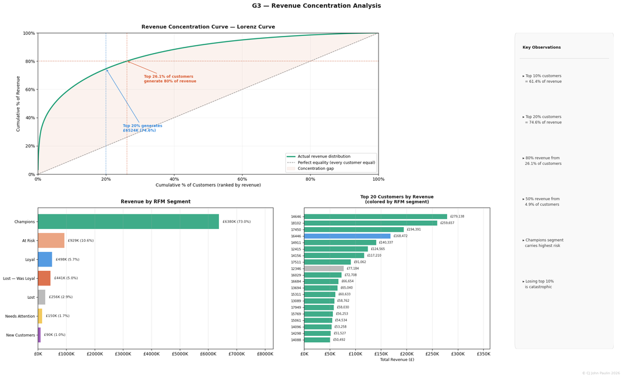

Revenue Concentration Thresholds

|  | Revenue Threshold | Customers Needed | % of Customer Base |
| --- | --- | --- | --- |
| 0 | Top 50% of revenue | 211 | 4.9% |
| 1 | Top 80% of revenue | 1,133 | 26.1% |
| 2 | Top 90% of revenue | 1,908 | 44.0% |

Revenue at Risk by Customer Tier

|  | Customer Tier | Revenue (£) | Revenue Share | Risk Level |
| --- | --- | --- | --- | --- |
| 0 | Top 10% of customers | £5,367,688.87 | 61.4% | 🔴 Critical |
| 1 | Top 20% of customers | £6,523,813.98 | 74.6% | 🔴 Critical |
| 2 | Champions segment | £6,380,162.75 | 73.0% | 🔴 Critical |
| 3 | At Risk segment | £929,327.65 | 10.6% | 🟡 High |

## G3 Insights — Revenue Concentration Analysis

### What the data shows

The store's revenue is heavily concentrated in a small group of customers. A tiny fraction of buyers is responsible for the vast majority of income — meaning the business is far more dependent on repeat high-value customers than it probably realizes.

### Key Findings

- **Top 26.1% of customers generate 80% of revenue** — slightly less concentrated than the classic 80/20 rule, but still means **8 out of 10 pounds comes from roughly 1 in 4 customers**
- **Top 10% of customers generate £5,367,688 (61.4% of revenue)** — just 434 customers are responsible for more than half of all money the store makes
- **Top 20% of customers generate £6,523,813 (74.6% of revenue)** — 868 customers out of 4,335 carry three quarters of the entire business
- **Champions segment alone generates 73.0% of revenue (£6,380,162)** — this one group is worth more than all other customer segments combined
- **At Risk segment has £929,327 drifting away** — these 765 customers used to buy regularly but are now going quiet. They have not left yet — but they are heading that way

### The Business Risk in Plain English

If the store lost its **top 10% of customers tomorrow** — just 434 people — it would lose **£5,367,688 or 61.4% of annual revenue.** No marketing campaign can replace that quickly. At the store's current rate of acquiring and retaining new customers, rebuilding that revenue would take years.

### This means...

The store is essentially running on the loyalty of a small group of high-value customers without knowing it. **If those customers leave, the business is in serious trouble.** The smart move is to identify these customers by name using the RFM Champion list, treat them differently from everyone else, and make them feel valued before a competitor does. At the same time, the **765 At Risk customers represent £929,327 that is still recoverable** — reaching out to them now, before they fully disengage, is the single highest return action the store can take today.

# Prescriptive — What should the business do?

# P1 — Customer Retention Strategy

### The Core Recommendation

Not all customers deserve the same attention. Based on the RFM analysis, the store should follow a **three-priority strategy** — protect the customers keeping the business alive, recover the ones drifting away, and stop wasting money on customers who will never return.

# Segment 1 — Champions

**1,315 customers · 73.0% of revenue · Avg spend £4,851**

**What to do:**

- **Create a VIP loyalty program** — reward points on every purchase redeemable for discounts. Champions already buy frequently (avg 9.34 orders) so points accumulate fast, giving them a reason to stay
- **Send a personal thank-you** — a simple email acknowledging their loyalty and offering an exclusive early access to new products costs nothing and builds emotional connection
- **Survey them** — ask what products they want that the store does not carry yet. Champions spending £4,851 on average know exactly what they want. Their answers are free market research
- **Never let them go quiet** — if a Champion has not purchased in 30 days, trigger an automatic check-in email with a personalized product recommendation based on their purchase history

# Segment 2 — At Risk

**765 customers · £929,327 at risk · Last purchase avg 84 days ago**

These customers used to buy regularly. They have not left yet but they are going quiet. The window to recover them is **now** — every week of delay makes recovery harder.

**Why this matters:** £929,327 is still recoverable. Even reactivating **20% of At Risk customers** recovers approximately **£185,865** — enough to fund a full year of retention campaigns.

# Segment 3 — Loyal

**608 customers · £498,047 revenue · Last purchase avg 23 days ago**

Loyal customers are buying recently and consistently but spending significantly less than Champions (£819 vs £4,851 avg). They are the most natural candidates to become Champions with the right push.

**What to do:**

- **Upsell with bundle offers** — if a Loyal customer regularly buys product A, offer them a bundle of A + B at a small discount. Increasing their average order value moves them closer to Champion monetary scores
- **Offer a spending milestone reward** — "Spend £1,000 this month and unlock VIP status." Give them a visible target to reach
- **Do not discount heavily** — Loyal customers are already buying without incentive. Deep discounts train them to wait for sales rather than buying at full price

**Why this matters:** Converting even **100 Loyal customers to Champions** at the Champion average spend of £4,851 adds approximately **£403,200 in incremental annual revenue.**

# Segment 4 — Lost — Was Loyal

**563 customers · £440,538 historical revenue · Silent for avg 234 days**

These customers were once regular buyers but have been gone for nearly 8 months on average. They are harder to recover than At Risk but still worth one serious attempt given their historical spend.

**What to do:**

- **Send one win-back email with a strong offer** — a 20-25% discount or a free gift with purchase. Make it time-limited (7 days) to create urgency
- **If they do not respond — stop** — do not send multiple follow-up emails. Customers gone for 234 days who ignore one strong offer are unlikely to respond to weaker ones. Respect their decision and redirect that budget elsewhere
- **Track who responds** — any Lost — Was Loyal customer who reactivates should be immediately moved into the At Risk nurture sequence to prevent them going quiet again

**Why this matters:** A 15% reactivation rate on this segment recovers approximately **84 customers** with an expected £782 average spend — adding roughly **£65,688 in recovered revenue.**

# Segment 5 — Lost and Needs Attention

**What to do:**

- **Do not invest in retention campaigns for this group** — the cost of reaching 825 customers with offers that have low probability of response is better spent protecting Champions and reactivating At Risk
- **Send one low-cost reactivation email** — a simple "Here is what is new at our store" newsletter with no discount. If they click, add them to the At Risk nurture sequence. If they do not, remove them from active marketing lists
- **Use their data differently** — analyze what these customers bought and when they left. If a pattern emerges (e.g. they all bought the same product category and never returned) that is a product quality signal worth investigating

**Why this matters:** Every pound spent trying to recover Lost customers is a pound not spent protecting Champions. Prioritization is the strategy.

### Priority Summary

| Priority | Segment | Action | Revenue Impact |
| --- | --- | --- | --- |
| 🔴 1st | Champions | VIP program + survey + 30-day alert | Protect £6,380,162 |
| 🔴 2nd | At Risk | Win-back campaign this month | Recover £185,865 (20%) |
| 🟡 3rd | Loyal | Upsell bundles + milestone rewards | Add £403,200 potential |
| 🟡 4th | Lost — Was Loyal | One strong offer, 7-day deadline | Recover £65,688 (15%) |
| 🟢 5th | Lost + Needs Attention | One newsletter, then deprioritize | Minimal spend |

### This means...

The store does not need a bigger marketing budget — it needs a **smarter one.** The data shows exactly who to spend on, in what order, and with what message. Focusing 80% of retention budget on **Champions and At Risk customers** while spending minimally on Lost segments is the highest return allocation the business can make with the information available today.

# P2 — Revenue Recovery Projection

**Objective:** Quantify the **financial impact** of acting on the P1 retention recommendations using three scenarios — Pessimistic, Realistic, and Optimistic.

**Key assumption:** Projections assume average spend per customer remains consistent with observed RFM values. Results are directional estimates, not guaranteed outcomes. Actual results depend on campaign execution quality and market conditions.

```
=== Pessimistic Scenario ===
Description:              Minimal effort — basic email only
Retention target:         25%
Additional customers/yr:  122
Stream 1 — Retention:     £592,466.66
Stream 2 — Reactivation:  £92,932.96
Stream 3 — Conversion:    £201,633.50
TOTAL RECOVERY:           £887,033.13

=== Realistic Scenario ===
Description:              Moderate effort — structured campaigns
Retention target:         30%
Additional customers/yr:  313
Stream 1 — Retention:     £1,518,195.83
Stream 2 — Reactivation:  £185,865.93
Stream 3 — Conversion:    £403,267.00
TOTAL RECOVERY:           £2,107,328.76

=== Optimistic Scenario ===
Description:              Full execution — VIP + campaigns + upsell
Retention target:         40%
Additional customers/yr:  695
Stream 1 — Retention:     £3,369,654.16
Stream 2 — Reactivation:  £325,265.38
Stream 3 — Conversion:    £806,534.00
TOTAL RECOVERY:           £4,501,453.53
```

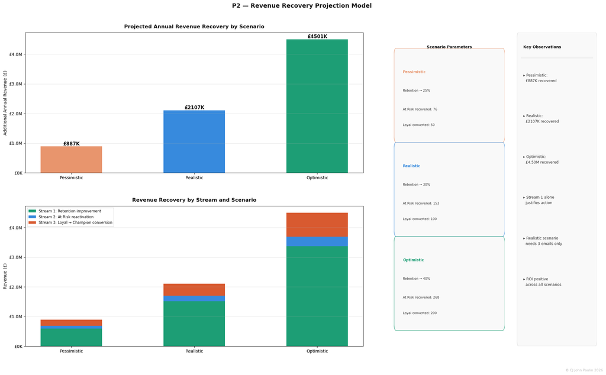

### What this model shows

Using real customer data from the RFM and cohort analysis, this model projects how much **additional annual revenue** the store can recover by acting on three simple retention initiatives — keeping new customers, winning back drifting ones, and encouraging moderate spenders to buy more.

### Three Scenarios — Pick Your Level of Effort

[output not shown]

### Where the Money Comes From

Each scenario pulls from three revenue streams:

| Stream | What Changes | Realistic Recovery |
| --- | --- | --- |
| 1 — Keep new customers longer | Retention improves 21.8% → 30% | £1,518,196 |
| 2 — Win back At Risk customers | 20% of 765 customers return | £185,866 |
| 3 — Move Loyal to Champion spend | 100 customers spend more | £403,267 |

### Assumptions

- Customer average spend stays consistent with current values
- Campaign quality is competent — poor execution lowers results
- These are **directional estimates**, not guaranteed outcomes

### This means...

The store is leaving **at least £887,000 on the table every year** with no retention system in place. The **Realistic scenario recovers £2,107,329** through three email campaigns — a few hours of work that pays for itself many times over.

# P3-Customer Lifetime Value Model

**Objective:** Calculate how much each **RFM customer segment** is worth to the business over the next 12 months — giving the store a clear number to put against any retention investment.

**Formula used:**

> CLV = Average Order Value × Annual Purchase Frequency × Retention Rate

**Why this matters:** Knowing a Champion is worth £X per year makes the cost of a loyalty program — say £50 per customer — an obvious investment, not a guessed expense.

```
=== Customer Lifetime Value by Segment ===
         Segment  customer_count  avg_order_value  avg_frequency  retention_rate  clv_per_customer  total_segment_clv
       Champions            1315       519.472623       9.339924            0.90       4366.651312       5.742146e+06
           Loyal             608       377.881222       2.167763            0.75        614.367743       3.735356e+05
         At Risk             765       371.731060       3.267974            0.35        425.182585       3.252647e+05
 Needs Attention             309       485.938835       1.000000            0.20         97.187767       3.003102e+04
Lost — Was Loyal             563       357.579570       2.188277            0.10         78.248318       4.405380e+04
   New Customers             259       346.915097       1.000000            0.22         76.321321       1.976722e+04
            Lost             516       496.117539       1.000000            0.05         24.805877       1.279983e+04

Total Portfolio CLV: £6,547,598.62
```

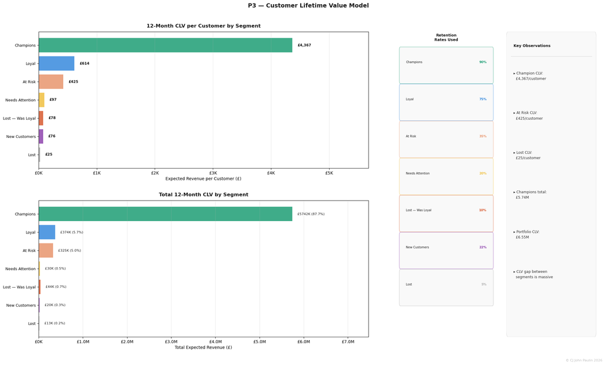

P3 — Customer Lifetime Value by Segment (12-Month Projection)

|  | Segment | Customers | Avg Order Value (£) | Avg Orders/Year | Retention Rate | CLV per Customer (£) | Total Segment CLV (£) |
| --- | --- | --- | --- | --- | --- | --- | --- |
| 0 | Champions | 1315 | £519.47 | 9.339924 | 90% | £4,366.65 | £5,742,146.47 |
| 1 | Loyal | 608 | £377.88 | 2.167763 | 75% | £614.37 | £373,535.59 |
| 2 | At Risk | 765 | £371.73 | 3.267974 | 35% | £425.18 | £325,264.68 |
| 3 | Needs Attention | 309 | £485.94 | 1.000000 | 20% | £97.19 | £30,031.02 |
| 4 | Lost — Was Loyal | 563 | £357.58 | 2.188277 | 10% | £78.25 | £44,053.80 |
| 5 | New Customers | 259 | £346.92 | 1.000000 | 22% | £76.32 | £19,767.22 |
| 6 | Lost | 516 | £496.12 | 1.000000 | 5% | £24.81 | £12,799.83 |

P3 — Maximum Retention Investment per Customer (20% of CLV)

[output not shown]

### What is CLV?

**Customer Lifetime Value (CLV)** is simply how much money the store can expect from one customer over the next 12 months based on how they currently buy. It answers the question every store owner should ask before spending on marketing:

> *"Is this customer worth spending money on — and how much?"*

### CLV by Customer Segment

| Segment | Customers | CLV per Customer | Max to Spend per Customer |
| --- | --- | --- | --- |
| **Champions** | 1,315 | **£4,367** | £873 |
| **Loyal** | 608 | **£614** | £123 |
| **At Risk** | 765 | **£425** | £85 |
| Needs Attention | 309 | £97 | £19 |
| Lost — Was Loyal | 563 | £78 | £16 |
| New Customers | 259 | £76 | £15 |
| Lost | 516 | £25 | £5 |

**Max to spend** = 20% of CLV — the safe limit to stay profitable on every retention action.

### What This Means in Plain English

- A **Champion customer is worth £4,367** to the business over the next year. Spending £50 on a VIP reward for them returns £4,317 — a no-brainer investment.
- An **At Risk customer is worth £425** if reactivated. A 15% discount offer costs roughly £60 per customer. If even half respond, the campaign pays for itself many times over.
- A **Lost customer is worth only £25.** One email is justified. Anything more wastes budget that should go toward Champions and At Risk.

### Total Portfolio Value

The store's **4,335 existing customers are worth a combined £6,547,599 over the next 12 months** — assuming current buying behavior continues unchanged.

Acting on the P1 and P2 recommendations grows this number. Doing nothing shrinks it as At Risk customers drift to Lost.

### This means...

The store now has a **number for every customer type.** No more guessing whether a discount or loyalty reward is worth it — compare the cost to the CLV and the answer is always clear. **Protect the £4,367 Champions first. Recover the £425 At Risk customers second. Stop spending on the £25 Lost customers entirely.**